# Analasys of query sequences with many hits

```r
knitr::opts_chunk$set(warning = FALSE,
                      error = TRUE,
                      echo = TRUE,
                      message = FALSE)
```

## Goal: To evaluate the content and similarity of sequences with many hits and GT containing genes.

## Date started: 08-05-2021

## Author: Soren Heidelbach

```r
library(dplyr)
library(stringr)
library(UpSetR)
library(seqinr)
library(msa)
library(ape)
library(data.table)
library(readxl)
library(readr)
library(rlist)

d.dir <- "C:/Users/heide/OneDrive - Aalborg Universitet/BIOT/8. semester/Project/Data"
```

Firstly, the PSI-BLAST hits are loaded. This is a quite time consuming process and the results are therefore written to the data folder, such that it is only run once and only loaded afterwards. After this the upset dataframe format is made. This also a **very** time consuming process, there same approach, run once and write and load afterwards.

Loading of data

```r
if (any(list.files(d.dir) %in% paste0(d.dir, "/psiblast_uniq.tsv"))) {
  psiblast_outputs <- list.files(paste0(d.dir, "/psiblast/"))
  psiblast <- data.frame()
  for (q in psiblast_outputs) {
    psi_path <- paste(d.dir, "/psiblast/", q, sep = "")
    psiblast <- rbind(
      psiblast,
      read.csv(
        file = psi_path,
        header = FALSE,
        sep = "\t",
        col.names = c(
          "Query_label",
          "Target_label",
          "Percent_identity",
          "align_length",
          "mismatch",
          "gap_opens",
          "start_query",
          "end_query",
          "start_target",
          "end_target",
          "E_value",
          "Bit score"
        )
      )
    )
    psiblast <- subset(psiblast, Percent_identity >= 20)
    print(q)
  }

  # Get best hit of each query-target pair.
  psiblast_uniq <- psiblast %>%
    group_by(Query_label, Target_label) %>%
    filter(Bit.score == max(Bit.score))
  write_tsv(psiblast_uniq, file = paste0(d.dir, "/psiblast_uniq.tsv"))
} else (
  psiblast_uniq <- read_tsv(paste0(d.dir, "/psiblast_uniq.tsv"))
)
```

| Query_label | Target_label | Percent_identity | align_length | mismatch | gap_opens | start_query | end_query | start_target | end_target | E_value | Bit score |
| --- | --- | --- | --- | --- | --- | --- | --- | --- | --- | --- | --- |
| algX | Rand_18-Q3-R56-63_BAT3C.326_00440 | 29.501 | 461 | 303 | 10 | 11 | 461 | 7 | 455 | 1.33e-167 | 486.0 |
| algX | EsbE_18-Q3-R3-47_MAXAC.188_00071 | 29.501 | 461 | 303 | 10 | 11 | 461 | 7 | 455 | 1.33e-167 | 486.0 |
| algX | Rand_18-Q3-R56-63_BAT3C.341_02406 | 26.273 | 491 | 319 | 15 | 1 | 471 | 1 | 468 | 3.75e-160 | 467.0 |
| algX | Aved_18-Q3-R54-62_MAXAC.392_00680 | 26.939 | 490 | 317 | 15 | 1 | 471 | 1 | 468 | 2.26e-159 | 465.0 |
| algX | Lyne_18-Q3-R50-59_MAXAC.325_cln_02514 | 26.939 | 490 | 317 | 15 | 1 | 471 | 1 | 468 | 2.26e-159 | 465.0 |
| algX | Rand_18-Q3-R56-63_BAT3C.341_02398 | 27.066 | 484 | 308 | 13 | 1 | 447 | 8 | 483 | 4.07e-159 | 467.0 |
| algX | Aved_18-Q3-R54-62_MAXAC.392_00686 | 27.273 | 484 | 307 | 13 | 1 | 447 | 8 | 483 | 1.06e-157 | 463.0 |
| algX | Lyne_18-Q3-R50-59_MAXAC.325_cln_02520 | 27.273 | 484 | 307 | 13 | 1 | 447 | 8 | 483 | 1.06e-157 | 463.0 |
| algX | Rand_18-Q3-R56-63_BAT3C.326_00437 | 26.735 | 490 | 322 | 13 | 4 | 464 | 3 | 484 | 2.09e-143 | 425.0 |
| algX | Aved_18-Q3-R54-62_MAXAC.392_00683 | 25.951 | 447 | 303 | 11 | 28 | 460 | 49 | 481 | 2.87e-140 | 416.0 |

[output cut: 990 more lines]

Defining function that are used several times

```r
# Making dataframe formatted for UpSet plot
get_upset_from_psiblast <- function(psiblast) {
  psi_list <- split(psiblast, f = str_sub(psiblast$Target_label, 1, -7))
  upset_df <- data.frame(matrix(ncol = length(unique(psiblast$Query_label)),
                                nrow = length(unique(psiblast$Target_label))
                                )
                         )
  colnames(upset_df) <- unique(psiblast$Query_label)
  rownames(upset_df) <- unique(psiblast$Target_label)
  genes <- unique(psiblast$Query_label)
  for (i in names(psi_list)) {
    df_temp <- psi_list[[i]] %>% as.data.frame()
    for (j in unique(df_temp$Target_label)) {
      uniqs <- df_temp$Query_label %>% unique()
      upset_df[j,]  <- c(genes %in% uniqs) %>%
        as.numeric()
    }
    print(paste(i, Sys.time(), sep=" - "))
  }
  return(upset_df)
}
check_upset_file <- function(psiblast, file) {
  if (!(any(list.files(d.dir) %in% file))) {
    upset_all <- get_upset_from_psiblast(psiblast)
    write_tsv(upset_all, file = paste0(d.dir, "/", file))
  } else (
    upset_all <- read_tsv(paste0(d.dir, "/", file))
  )
  return(upset_all)
}
write_query_fasta_from_genes <- function(genes) {
  query_fasta <- list()
  for (i in list.files(paste0(d.dir, "/Queries_final/"))) {
    for (j in list.files(paste0(d.dir, "/Queries_final/", i))) {
      path <- paste0(paste0(d.dir, "/Queries_final/", i, "/", j))
      suppressWarnings(
        query_fasta <- append(query_fasta, read.fasta(path))
      )
    }
  }
  query_fasta_top <- query_fasta[genes]
  write.fasta(
    query_fasta_top,
    names = names(query_fasta_top),
    file.out = paste0(d.dir, "temp.fa"))
}
```

Evaluation of the top 10 hits. The top 10 most abundant hits are investigated, what are they, what are their function and what queries are they from.

```r
# Get top 10 queries by number of hits
n_hits <- table(psiblast_uniq$Query_label) %>% as.data.frame()
psiblast_top <- psiblast_uniq %>%
  subset(Query_label %in% n_hits[n_hits$Freq %in% tail(sort(n_hits$Freq), 10),"Var1"])
upset_top <- check_upset_file(psiblast_top, "upset_top_genes.tsv") %>% as.data.frame()


UpSetR::upset(upset_top, nsets = ncol(upset_top),
  number.angles = 0, point.size = 2.5, line.size = 1, text.scale = 1.2,
  order.by = "freq",
  mainbar.y.label = "Number of Incommon Hits",
  sets.x.label = "Total Unique Hits"
)
```

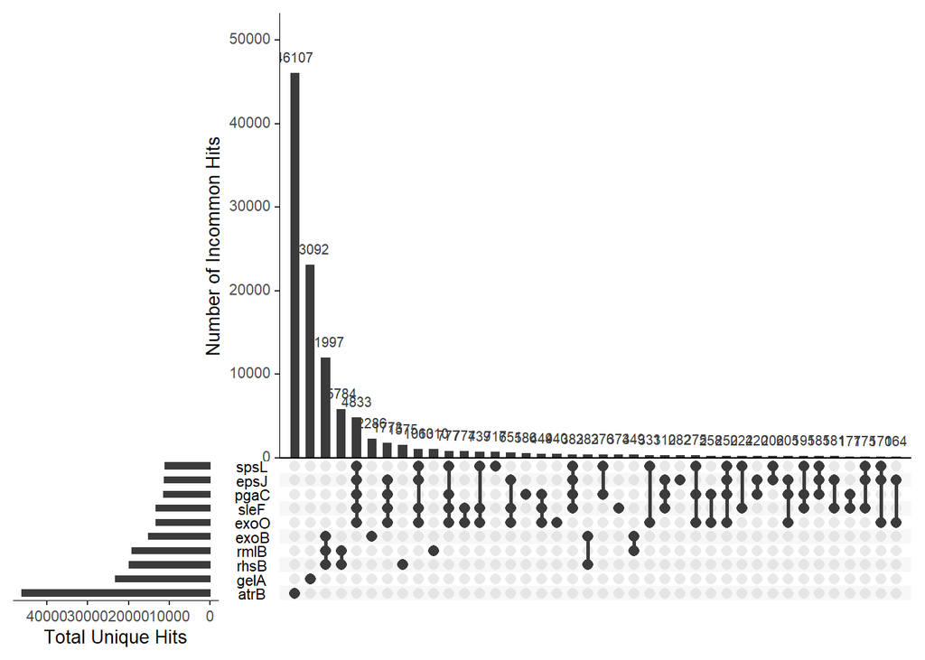

An MSA and phylogenetic tree is made to investigate similarities between these queries.

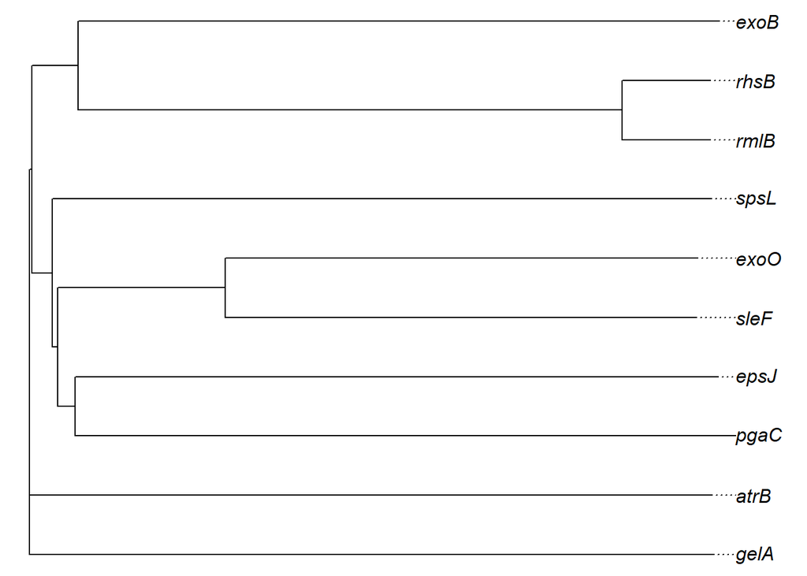

```r
# MSA of sequences
write_query_fasta_from_genes(colnames(upset_top))
seqs <- readAAStringSet(paste0(d.dir,"temp.fa"))
MSA <- msa(
  seqs,
  method = "Muscle",
  order="aligned")

# Printing MSA to .tex file
msaPrettyPrint(
  MSA,
  file = "MSA_top10_Musc.tex",
  output="tex",
  showNames="left",
  showLogo="top",
  askForOverwrite=FALSE,
  verbose=FALSE,
)

# Phylogenetic tree
MSA <- msaConvert(MSA, type="seqinr::alignment")
dist.matrix <- dist.alignment(MSA, "identity") %>% as.matrix ()
tree <- njs(dist.matrix)
plot.phylo(
  tree,
  srt=0,
  adj=0,
  show.node.label = T,
  no.margin = T,
  align.tip.label = 3
)
```

Next the GT and synthase (SY) genes investigated

```r
# Loading metadata of query genes
query_metadata <- excel_sheets(paste0(d.dir,"/Query_figur.xlsx")) %>%
  sapply(function(X) read_xlsx(paste0(d.dir,"/Query_figur.xlsx"), sheet = X, skip = 1), USE.NAMES = T) %>%
  lapply(as.data.frame) %>%
  `[`(!(names(.) %in% c("Abbreveations", "HA_S_pyogenes"))) %>%
  rbindlist()
query_metadata_GT <- subset(query_metadata, Function %in% c("GT", "SY"))
```

Firstly, an upset plot is made to evaluate to incommen hits of all the gt containing genes.

```r
# Subsetting psiblast to gt only
psiblast_gt <- subset(psiblast_uniq, Query_label %in% query_metadata_GT$Genename)
upset_gt <- check_upset_file(psiblast_gt, "upset_gt.tsv") %>% as.data.frame()

UpSetR::upset(upset_gt,  nsets = ncol(upset_gt),
  number.angles = 0, point.size = 1, line.size = 0.7, text.scale = 0.8,
  order.by = "freq",
  mainbar.y.label = "Number of Incommon Hits",
  sets.x.label = "Total Unique Hits"
)
```

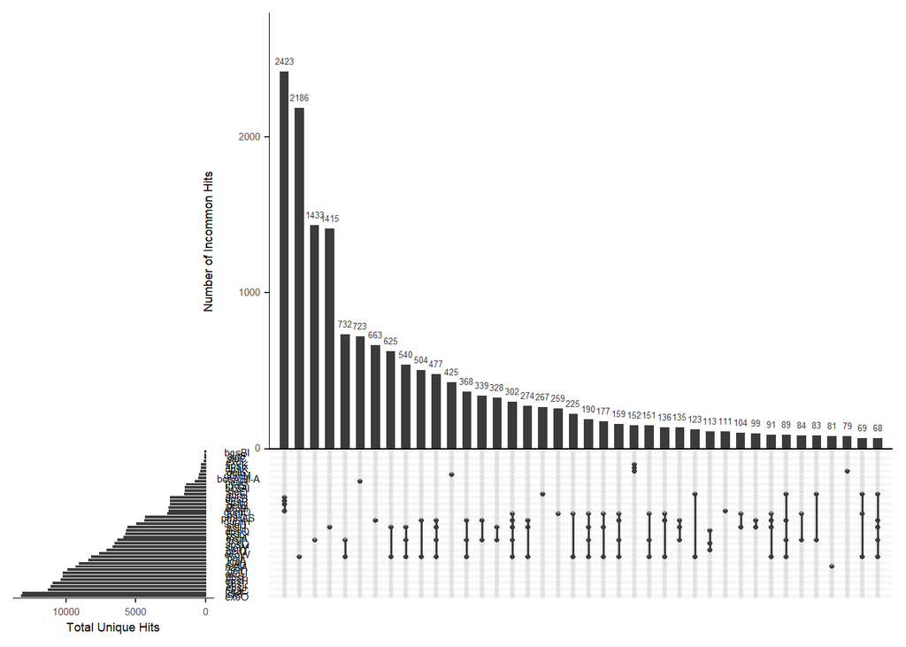

Next the sequences of the queries are aligned and evaluated in a phylogenetic tree and in an MSA.

```r
write_query_fasta_from_genes(colnames(upset_gt))
```

```r
# MSA of sequences
seqs <- readAAStringSet(paste0(d.dir,"temp.fa"))
MSA <- msa(
  seqs,
  method = "ClustalOmega",
  order="aligned")
```

```
## using Gonnet
```

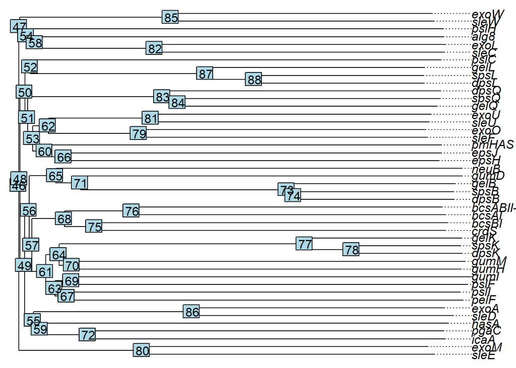

```r
# Printing MSA to .tex file
msaPrettyPrint(
  MSA,
  file = "MSA_gt_ClusO.tex",
  output="tex",
  showNames="left",
  showLogo="top",
  askForOverwrite=FALSE,
  verbose=FALSE,
)

# Phylogenetic tree
MSA <- msaConvert(MSA, type="seqinr::alignment")
dist.matrix <- dist.alignment(MSA, "identity") %>% as.matrix ()
tree <- njs(dist.matrix)
plot.phylo(
  tree,
  srt=0,
  adj=0,
  show.node.label = T,
  no.margin = T,
  align.tip.label = 3
)
nodelabels()
```

From the MSA, very little conservation of any amino acids across all groups is observed, although some subset of GT’s/synthases have high conservations. Evaluating the tree, it is obvious that dps, sps and gel genes cluster together, which is kinda expected, as they are all sphingans. Also exo and sle genes are grouped together. The crdS gene is also placed along ith the bcs genes. To further evaluate these observations, the general tree is subsetted (by the nodelabels in plot) and the tip labels used to perform new MSA and plot new trees (from the new MSA)

A function is defined that extract a subtree by the specified node, which is displayed in the above tree.

```r
# Function that extract sub tree from node label
get_subtree_from_node_label <- function(tree, node) {
  sub_trees <- subtrees(tree, wait = T)
  sub_tree <- sub_trees %>% lapply(
    function(x) {
      if(x$name == node) {
        return(x)
      } else {
        return(NULL)
      }
    }
  )
  sub_tree <- sub_tree[!(sub_tree %>% lapply(is.null) %>% unlist())] %>% `[[`(1)
}
```

After this a function is made that perform the general analasys used so far (UpSet, MSA & tree) on the subtree specified from the node label.

[output not shown]

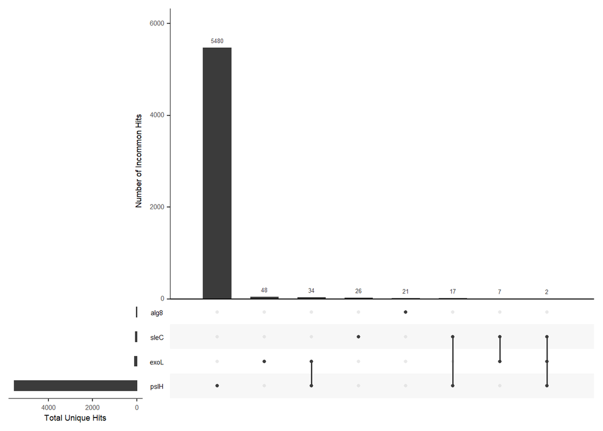

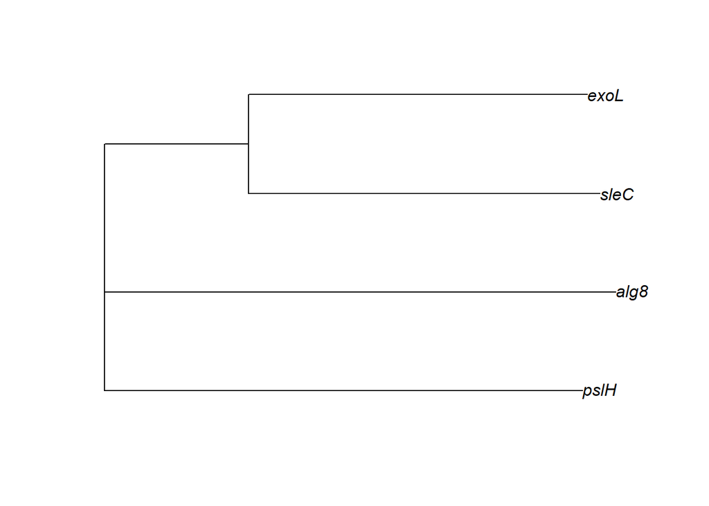

```r
msa_tree_analasys_subtree_node <- function(tree, node, upset_df) {
  sub_tree <- get_subtree_from_node_label(tree, node)
  upset_gt_n <- upset_df[,sub_tree$tip.label]
  upset_gt_n <- upset_gt_n[!(rowSums(upset_gt_n) < 1),]
  # Upset plot
  print(UpSetR::upset(upset_gt_n,
    number.angles = 0, point.size = 1, line.size = 0.7, text.scale = 0.8,
    #nsets = length(colnames(upset_gt_n)),
    order.by = "freq",
    mainbar.y.label = "Number of Incommon Hits",
    sets.x.label = "Total Unique Hits"
  ))

  # Subsetting and loading fasta files
  write_query_fasta_from_genes(colnames(upset_gt_n))
  suppressWarnings(
    {myseqs <- readAAStringSet(paste0(d.dir, "temp.fa"), )}
  )

  MSA <- msaMuscle(myseqs)

  # tex file of MSA
  msaPrettyPrint(
    MSA,
    output="tex",
    showNames="left",
    file = paste0("MSA_gt_",
                 {paste(sub_tree$tip.label, collapse="_") %>% substr(1, 14)} ,
                 "_Musc.tex"),
    showLogo="top",
    askForOverwrite=FALSE,
    verbose=FALSE
  )
  # New tree
  MSA <- msaConvert(MSA, type="seqinr::alignment")
  dist_matrix <- dist.alignment(MSA, "identity") %>%
    as.matrix ()
  rm(MSA, upset_gt_n)
  tree <- njs(dist_matrix)
  plot.phylo(tree)
}
msa_tree_analasys_subtree_node(tree, "54", upset_gt)
```

```r
msa_tree_analasys_subtree_node(tree, "87", upset_gt)
```

[output not shown]

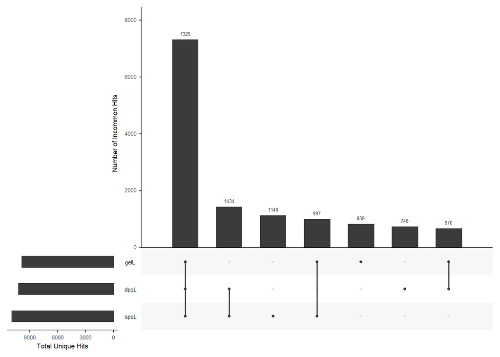

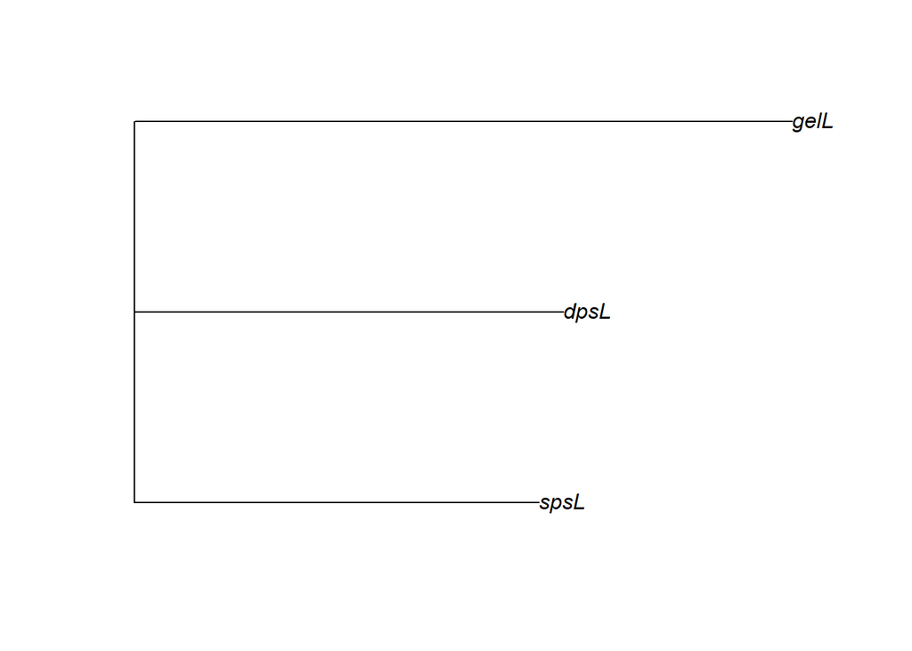

```r
msa_tree_analasys_subtree_node(tree, "83", upset_gt)
```

[output not shown]

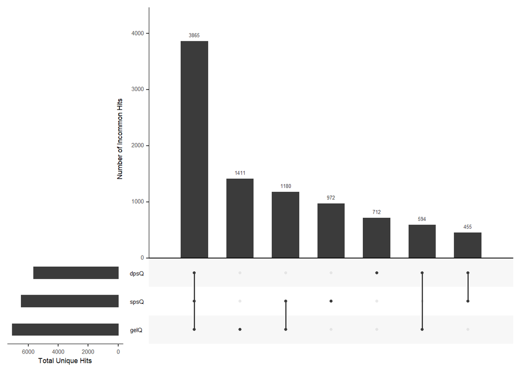

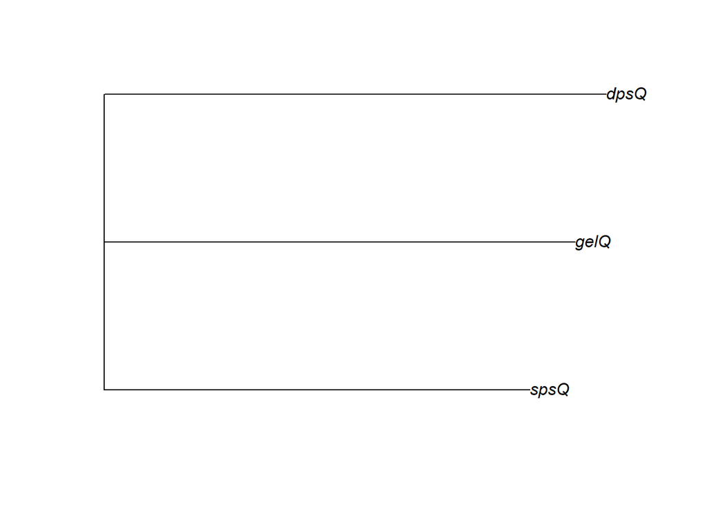

```r
msa_tree_analasys_subtree_node(tree, "62", upset_gt)
```

[output not shown]

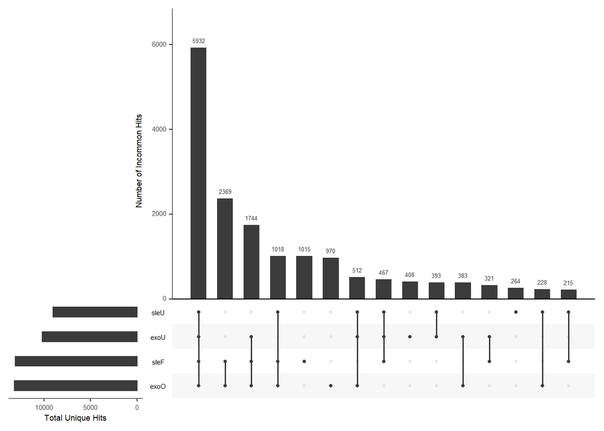

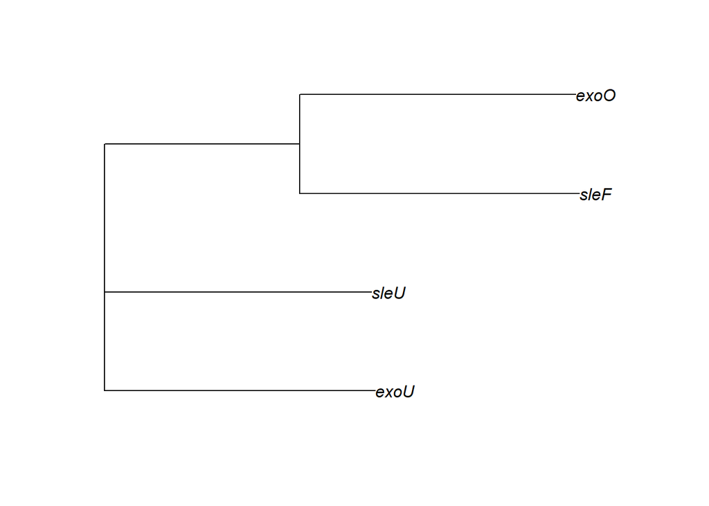

```r
msa_tree_analasys_subtree_node(tree, "60", upset_gt)
```

[output not shown]

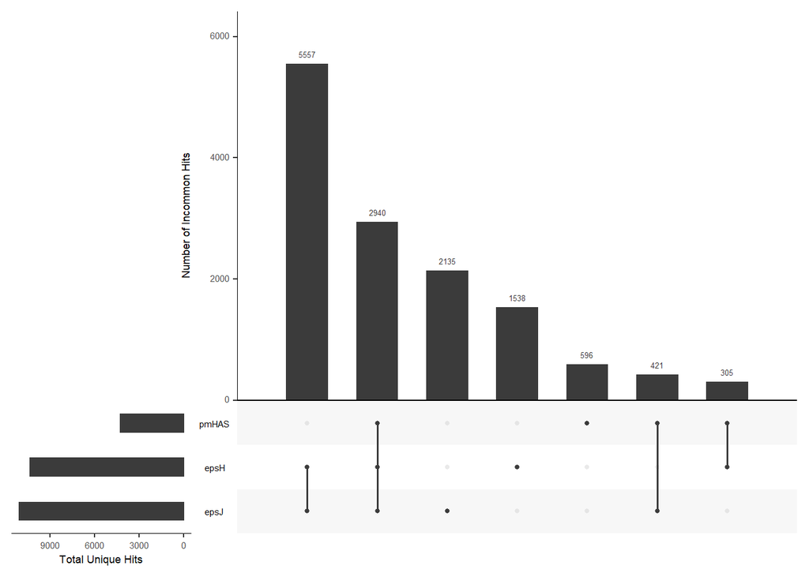

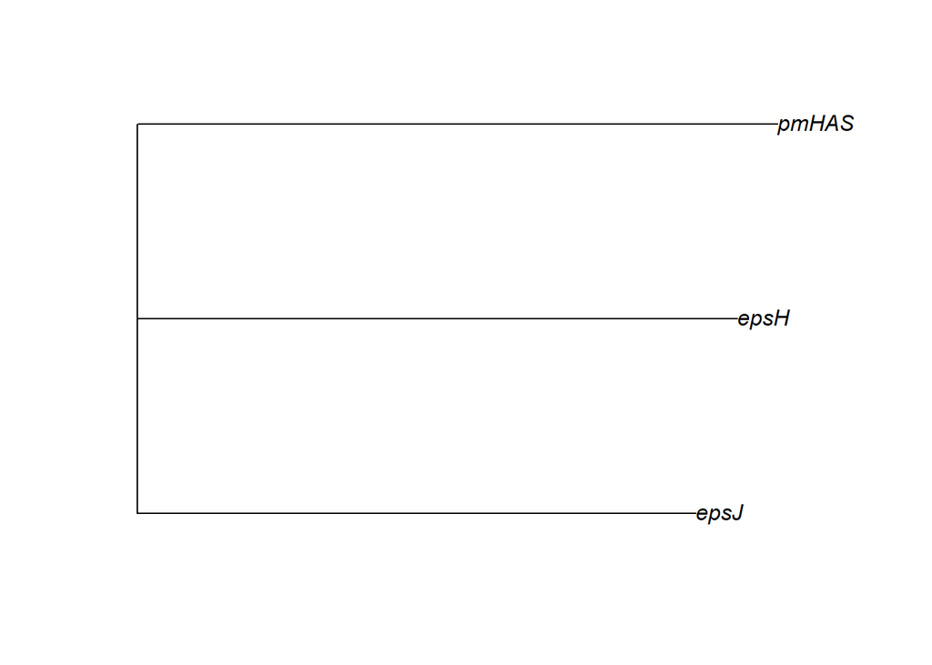

```r
msa_tree_analasys_subtree_node(tree, "68", upset_gt)
```

[output not shown]

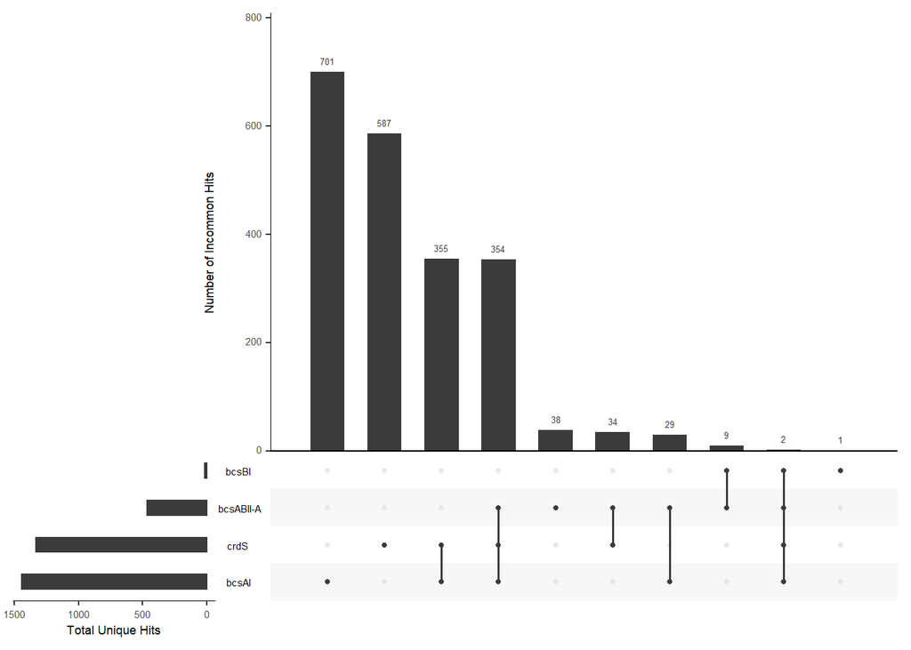

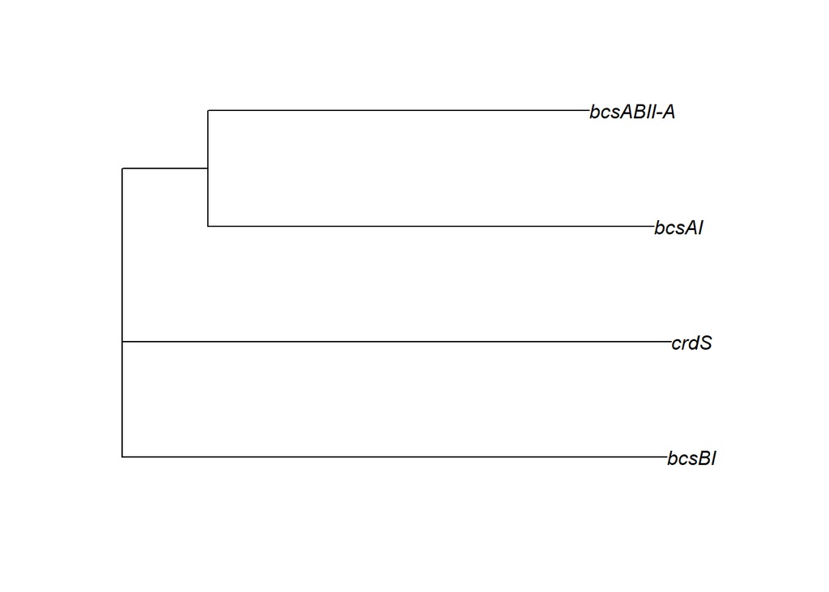

```r
msa_tree_analasys_subtree_node(tree, "64", upset_gt)
```

[output not shown]

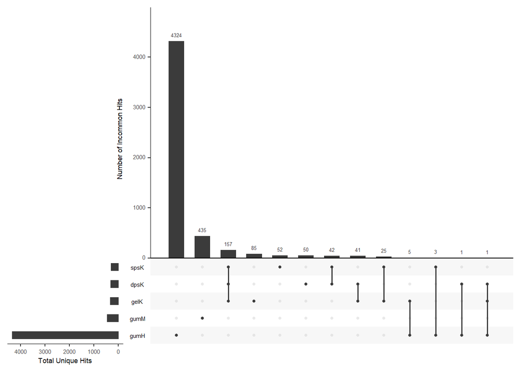

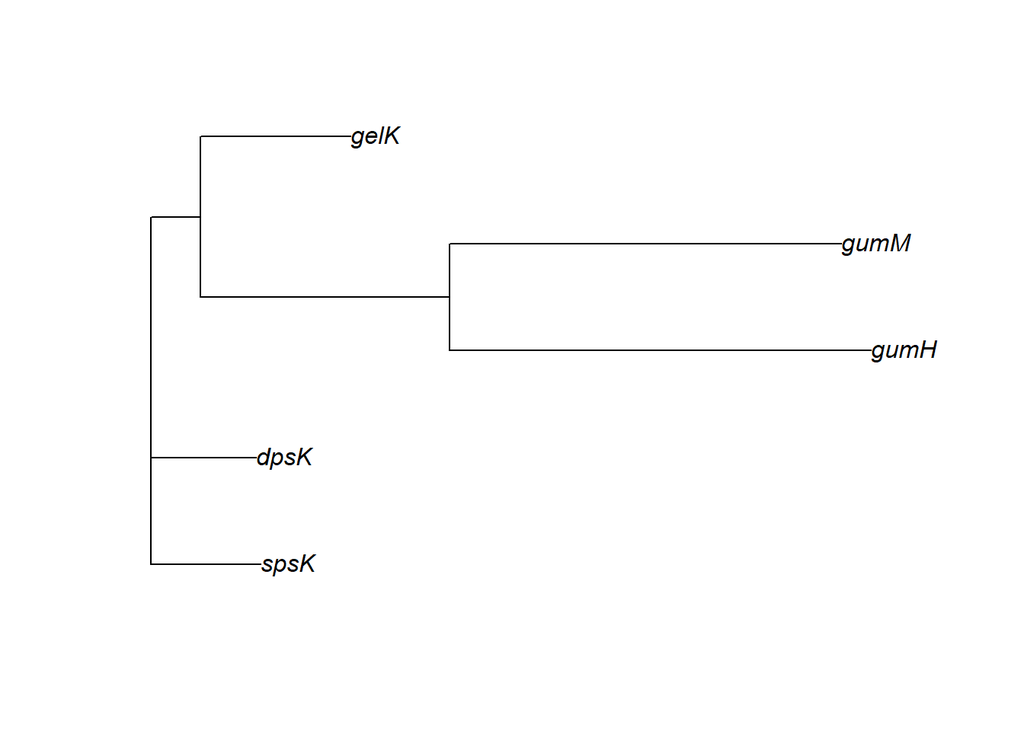

```r
msa_tree_analasys_subtree_node(tree, "63", upset_gt)
```

[output not shown]

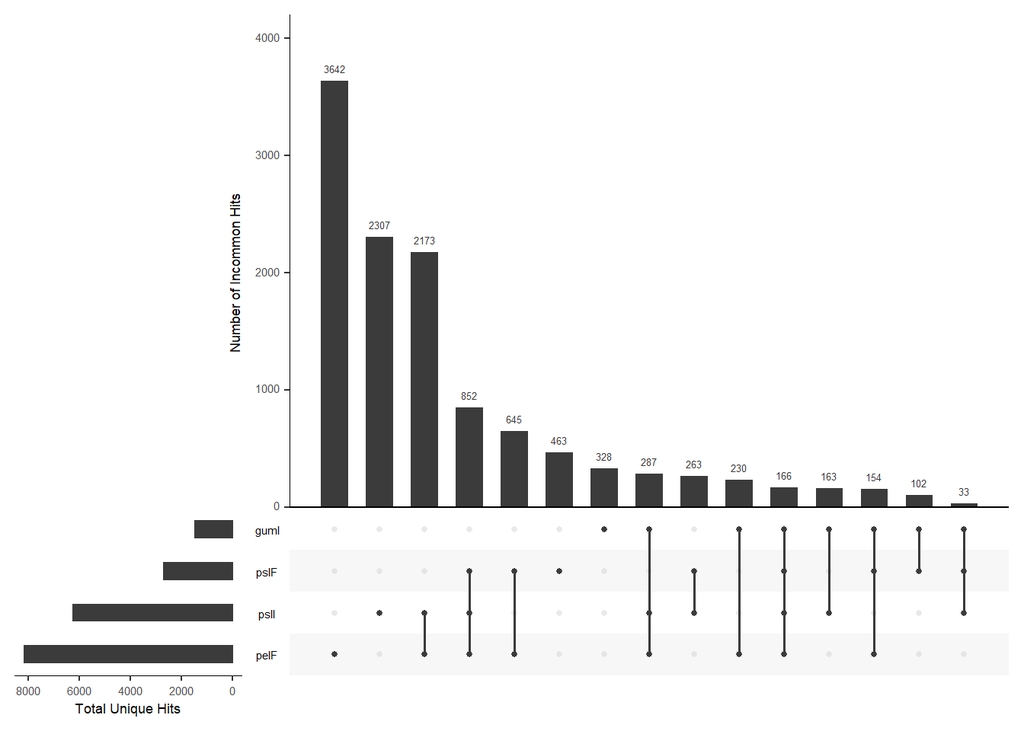

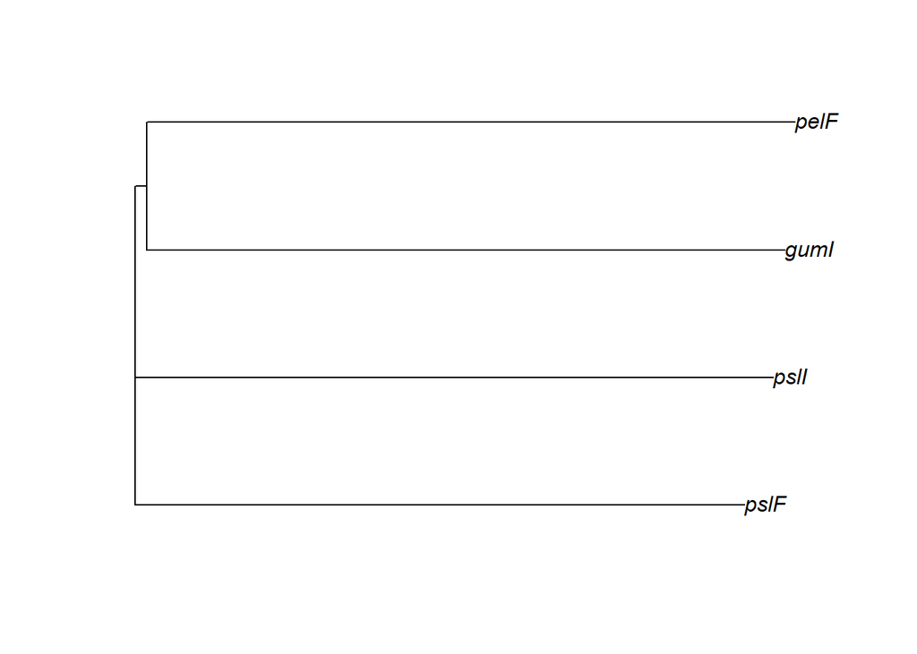

```r
msa_tree_analasys_subtree_node(tree, "55", upset_gt)
```

[output not shown]

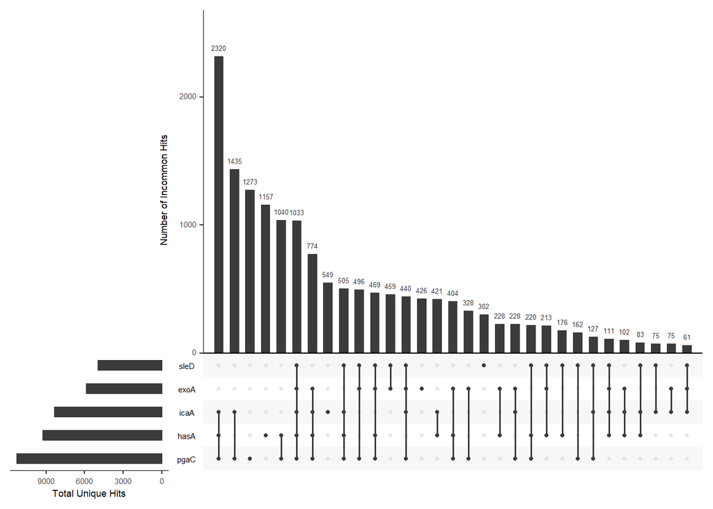

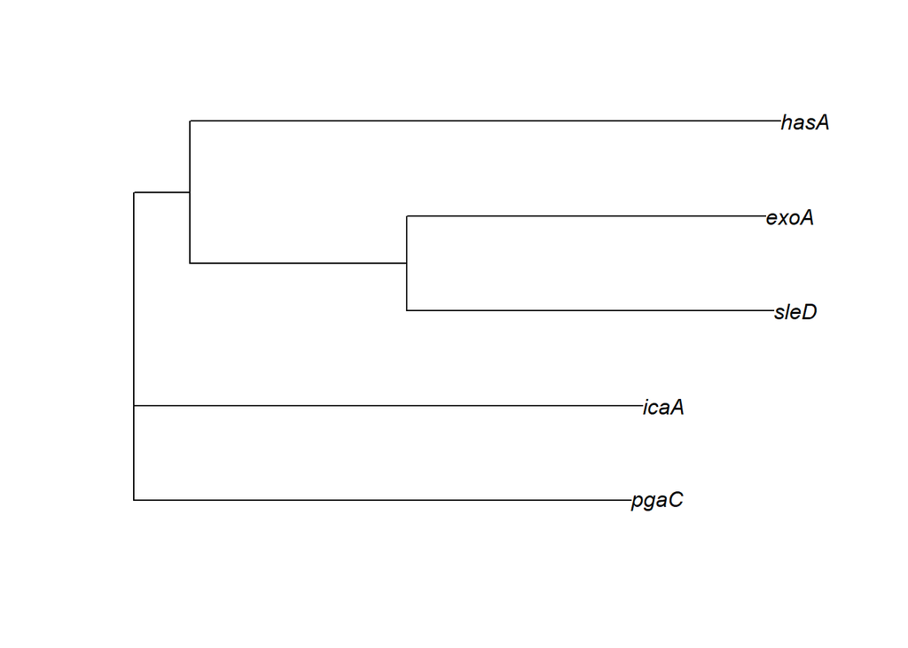